# Household Pulse Survey (HPS; US Census)

## Periods

[output not shown]

- E: Employment
- V: Vaccination
- W: Two-week period

# Getting data tables (aggregate).

For employment we need tables 1 and 2 under *Employment Tables*. (e.g. https://www.census.gov/data/tables/2020/demo/hhp/hhp18.html)

For vaccination (starting 06.01.21) we need table 5 under *Health Tables* (e.g. https://www.census.gov/data/tables/2021/demo/hhp/hhp22.html)

# Cleaning tables

Tips here: https://www.sophieheloisebennett.com/posts/excel-sheet-cleaning/

## Employment

### Employment1

**Phase 3:** “Have you, or has anyone in your household experienced a loss of employment income since March 13, 2020?”

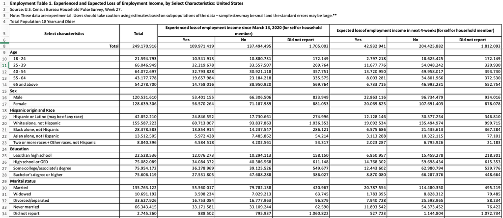

**Phase 3.1 (current):** “Have you, or has anyone in your household experienced a loss of employment income in the last 4 weeks?”

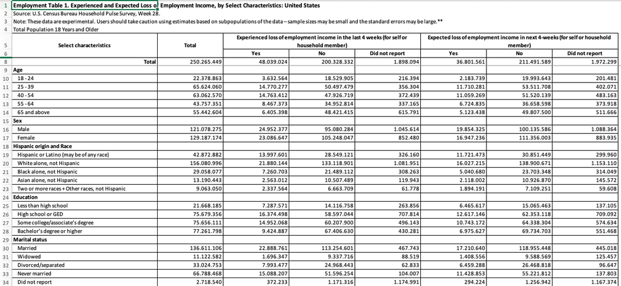

As the first 5 rows have been skipped, the resulting df looks like this:

```r
head(P1_emp1)
```

[output not shown]

### Employment2

**Questions**:

- Phase 3.0 & 3.1: “In the last 7 days, did you do ANY work for either pay or profit? Select only one answer.” [YES | NO]

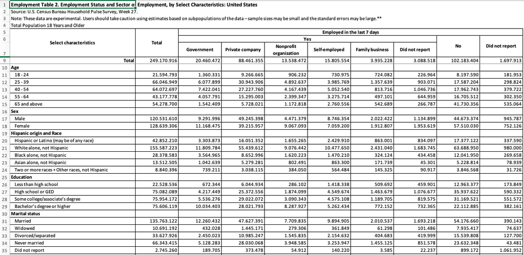

Phase 3 (P1 - P10)

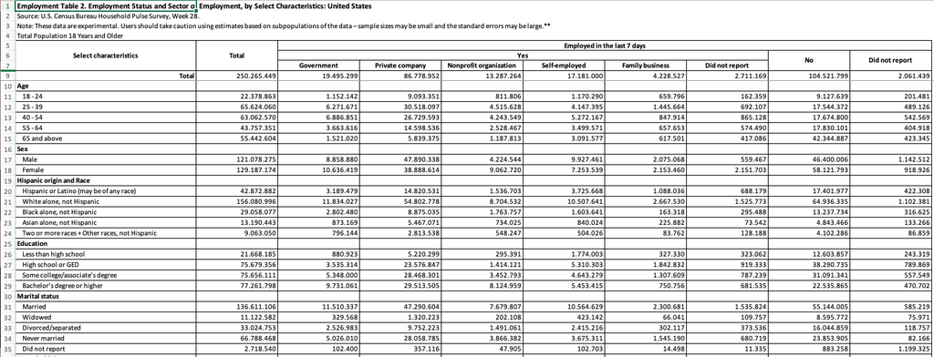

```r
cleanEmp2 <- function(df){

  # Remove all rows that are completely empty:
  df <- df %>%
    filter_all(any_vars(complete.cases(.)))


  df <- df %>%
    slice(2:11) %>% # Select only rows we're interested in (i.e. 2 - 11)
    filter(...1 != "Age" & ...1 != "Sex") %>% # and remove "Age" and "Sex" columns.
    mutate(across(contains("Yes"),as.double)) %>% # change column type from 'char' to 'double'
    mutate(Yes = rowSums(select(., contains("Yes")))) %>% # sum up all the "Yes" columns (we don't care about sector)
    # Change var names
    mutate(demog = ...1,
           emp_loss_total = ...2,
           emp_loss_yes = Yes,
           emp_loss_no = No) %>%
    mutate(emp = emp_loss_yes/(emp_loss_yes + emp_loss_no)) %>% # Calculate ratio
    select(demog, emp)

  # # Convert to wide (this makes more sense for combining all the periods)
  df_wide <- spread(df, demog, emp)

  return (df_wide)
}

emp2 <- allPeriods(vars_emp2, "emp2")
emp2
```

[output not shown]

### Vaccination

**Questions**:

- Phase 3.0:
  - “Have you received a COVID-19 vaccine?”
    - YES: “Did you receive (or do you plan to receive) all required doses?”
    - NO: “Once a vaccine to prevent COVID-19 is available to you, would you…” [Definitely get | Probably get | Probably NOT | Definitely NOT]
- Phase 3.1:
  - “Have you received a COVID-19 vaccine?”
    - YES: “Did you receive (or do you plan to receive) all required doses?”
    - NO: “Once a vaccine to prevent COVID-19 is available to you, would you…” [Definitely get | Probably get | Unsure about getting the vaccine | Probably NOT | Definitely NOT]

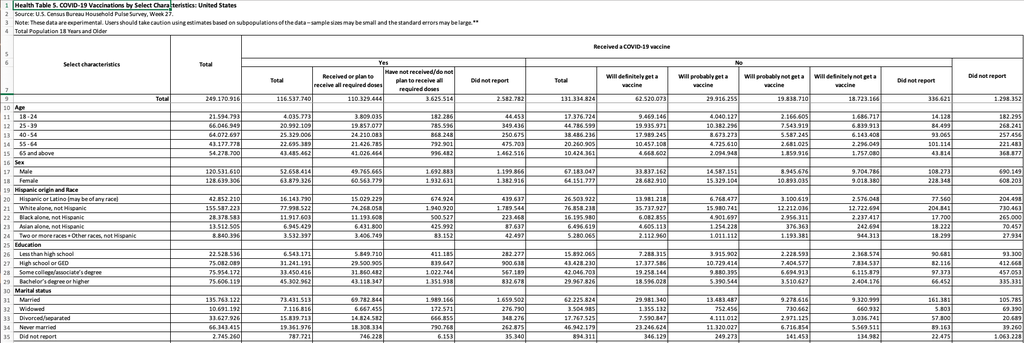

Phase 3 (P1 - P10)

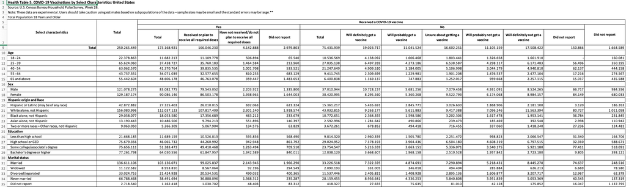

#### Transformations.

```r
head(P10_vacc)
```

[output not shown]

**Phase 3.0:**

…1: demog : Demographics …2: total : Total (respondends Yes/No/DNR) Yes…3: yes_total : Total *YES* responses Yes…4: yes_all : Received or plan to receive all required doses Yes…5: yes_some : Have not received/do not plan to receive all required doses Yes…6: yes_nr : Did not report (*YES* but did not report whether they will get all doses) No…7: no_total : Total *NO* responses No…8: no_def_will : Will definitely get a vaccine (But have not received any doses yet) No…9: no_prob_will: Will probably get a vaccine (~) No…10: no_prob_not : Will probably not get a vaccine No…11: no_def_not : Will definitely not get a vaccine No…12: no_nr : Did not report (*NO* but did not report whether they will or not) Did not report: total_nr : Did not report *YES* or *NO*

```r
head(P11_vacc)
```

[output not shown]

**Phase 3.1**:

…1: demog : Demographics …2: total : Total (respondends Yes/No/DNR) Yes…3: yes_total : Total *YES* responses Yes…4: yes_all : Received or plan to receive all required doses Yes…5: yes_some : Have not received/do not plan to receive all required doses Yes…6: yes_nr : Did not report (*YES* but did not report whether they will get all doses) No…7: no_total : Total *NO* responses No…8: no_def_will : Will definitely get a vaccine (But have not received any doses yet) No…9: no_prob_will: Will probably get a vaccine (~) No…10: no_unsure : Unsure about getting a vaccine/ No…11: no_prob_not : Will probably not get a vaccine No…12: no_def_not : Will definitely not get a vaccine No…13: no_nr : Did not report (*NO* but did not report whether they will or not) Did not report: total_nr : Did not report *YES* or *NO*

```r
testFunc <- cleanVacc(P11_vacc, "3.1")
testFunc
```

[output not shown]

…1: demog : Demographics …2: total : Total (respondends Yes/No/DNR) Yes…3: yes_total : Total *YES* responses Yes…4: yes_all : Received or plan to receive all required doses Yes…5: yes_some : Have not received/do not plan to receive all required doses Yes…6: yes_nr : Did not report (*YES* but did not report whether they will get all doses) No…7: no_total : Total *NO* responses No…8: no_def_will : Will definitely get a vaccine (But have not received any doses yet) No…9: no_prob_will: Will probably get a vaccine (~) No…10: no_unsure : Unsure about getting a vaccine/ No…11: no_prob_not : Will probably not get a vaccine No…12: no_def_not : Will definitely not get a vaccine No…13: no_nr : Did not report (*NO* but did not report whether they will or not) Did not report: total_nr : Did not report *YES* or *NO*

### Notes:

Each table has a standard error table associated with it. The details of how these were derived can be found in the *Technical documentation* available for each week in part, e.g. [Week 28](https://www2.census.gov/programs-surveys/demo/technical-documentation/hhp/Phase3-1_Source_and_Accuracy_Week_28.pdf).

The structure should be identical in most cases, so the same functions could be used to get these. Unsure at this point how we’d be using these so will not get them just yet.